# Udacity_Project_EDA

Edward Carter

7/21/2020

========================================================

```
## 'data.frame':    979 obs. of  27 variables:
##  $ SITE_ID      : chr  "YOS404" "JOT403" "SEK430" "YOS404" ...
##  $ TYPE         : chr  "C" "C" "C" "C" ...
##  $ DATEON       : Date, format: "2020-04-14" "2020-04-14" ...
##  $ DATEOFF      : Date, format: "2020-04-21" "2020-04-21" ...
##  $ TSO4         : num  0.587 0.663 0.827 0.385 0.531 ...
##  $ TNO3         : num  0.254 0.637 0.387 0.166 0.256 ...
##  $ TNH4         : num  0.133 0.268 0.367 0.137 0.145 ...
##  $ CA           : num  0.0674 0.1408 0.0432 0.0958 0.0486 ...
##  $ MG           : num  0.0281 0.0335 0.017 0.0156 0.0198 0.0196 NA 0.0203 0.0138 0.0328 ...
##  $ NA.          : num  0.114 0.1568 0.0756 0.0307 0.1081 ...
##  $ K            : num  0.0351 0.0334 0.051 0.021 0.0232 0.0496 NA 0.0328 0.0242 0.0454 ...
##  $ CL           : num  0.0146 0.0209 0.0163 0.0145 0.0271 0.0158 NA NA NA NA ...
##  $ NSO4         : num  0.0444 0.0304 0.0484 0.0582 0.0534 0.0959 NA 0.0813 0.0602 0.0605 ...
##  $ NHNO3        : num  0.293 0.865 0.472 0.507 0.179 ...
##  $ WSO2         : num  0.0866 0.1507 0.1875 0.0723 0.0921 ...
##  $ WNO3         : num  NA NA NA NA NA ...
##  $ TOTAL_SO2    : num  0.116 0.171 0.22 0.111 0.128 ...
##  $ TOTAL_NO3    : num  0.543 1.488 0.852 0.665 0.432 ...
##  $ FLOW_VOLUME  : num  34.2 32.9 30.7 34.4 34 ...
##  $ VALID_HOURS  : int  166 159 167 169 166 167 NA 167 146 170 ...
##  $ COMMENT_CODES: chr  "T01 T04" "T04" "T04" "" ...
##  $ STD2LOCAL_CF : num  1.14 1.11 1.02 1.14 1.12 ...
##  $ TEMP_SOURCE  : chr  "sa" "sa" "sa" "sa" ...
##  $ QA_CODE      : int  3 3 3 3 3 3 3 3 3 3 ...
##  $ UPDATE_DATE  : Date, format: "2020-06-30" "2020-06-30" ...
##  $ YEAR         : chr  "2020" "2020" "2020" "2004" ...
##  $ MONTH        : chr  "04" "04" "04" "03" ...
```

> The United States Environmental Protection Agency maintains a program known as the Clean Air Status and Network (CASTNET). This program is a long-term environmental monitoring network. This network is maintained in the United States and Canada and consists of 97 sites. Established by the 1990 Clean Air Act Amendments to provide accountability for emission reduction programs by reporting trends in pollutant concentrations and acidic deposition. The dataset utilized in this project is a measurement of the weekly ambient concentrations of Suflate (SO4), Nitrate (NO4), Ammonium (NH4), Calcium (Ca), Magnesium (Mg), Sodium (Na), Potassium (K), Chloride (Cl), Nitric Acid (NO3), and Sulfur Dioxide (NO3).

> > Particle Pollution (PM) inlcudes: Sulfate, Nitrate, Ammonium, Magnesium, Calcium, Potassium, Sodium and Chloride. Based on the 1990 Clean Air Act these fine inhalable particulate matter (PM2.5) thresholds are (per cubic meter of air): 12.0 micrograms (Annual Mean over 3 years) 15.0 micrograms (Annual Mean over 3 years) 35.0 micrograms (98th Percentile averaged over 3 years)

# Univariate Plots Section

The following graph shows the Air Flow Volume. This shows a centralized grouping around the 30-35 m3 amount. The graph provides a baseline understanding that the identified sites should all have the same Air Flow Volume.

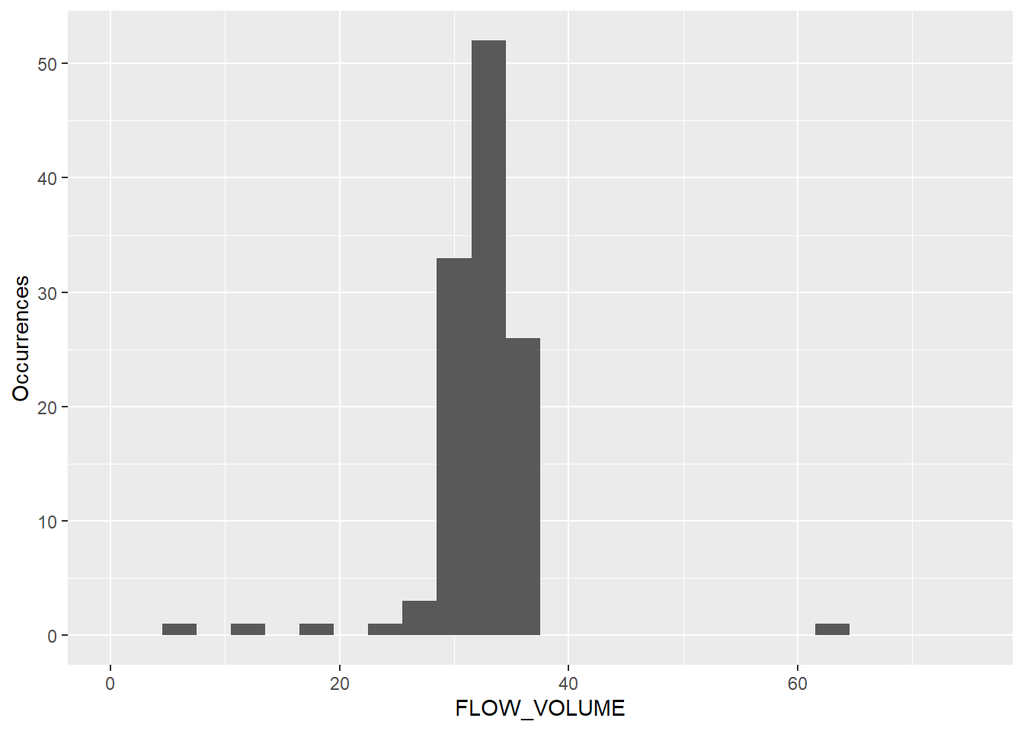

```
##    Min. 1st Qu.  Median    Mean 3rd Qu.    Max.    NA's
##   5.249  30.923  32.503  35.092  34.394 204.912       1
```

The next graph shows that Sulfate (SO4) is normally low with the majority of occurrences happening around the .5 micro-gram level. The outlier of above 2.0 is a likely contributor to a site’s low rating on the Air Quality Rating.

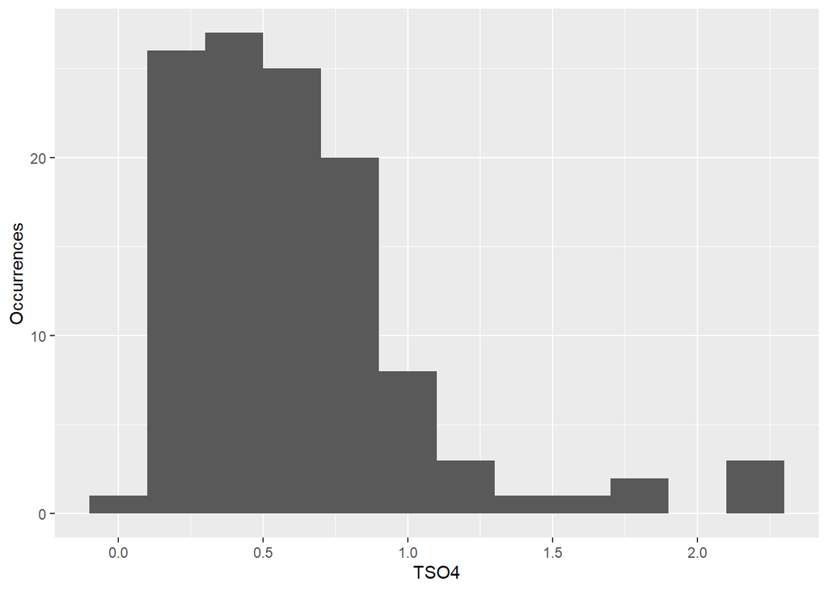

```
##    Min. 1st Qu.  Median    Mean 3rd Qu.    Max.    NA's
##  0.0995  0.3160  0.5238  0.6115  0.7591  2.2513       5
```

This graph shows that nitrates are usually below the 1.5 micro-gram. Again an outlier is present at 4 micro-gram.

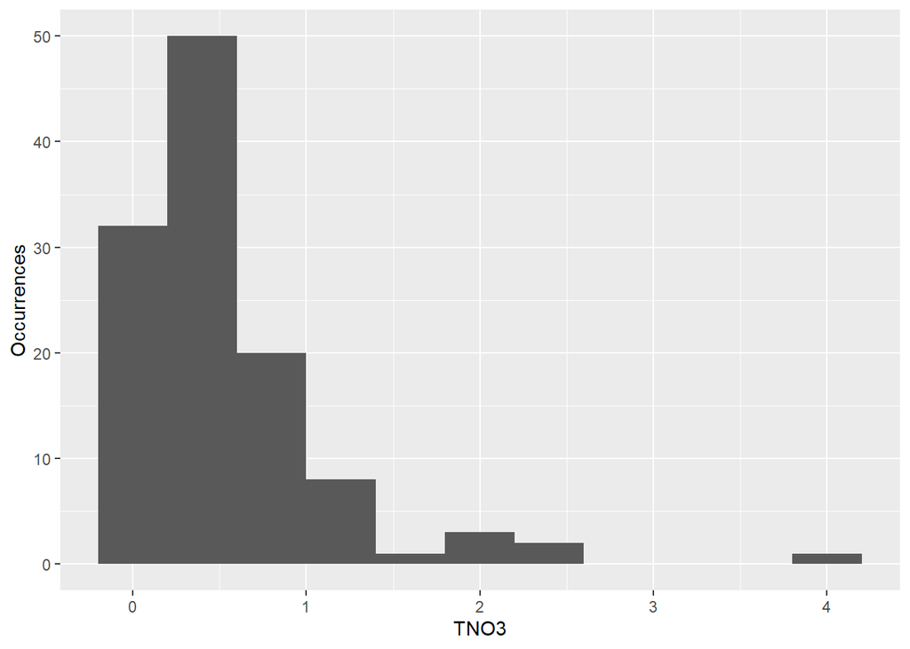

```
##    Min. 1st Qu.  Median    Mean 3rd Qu.    Max.    NA's
##  0.0316  0.1856  0.3957  0.5359  0.6680  3.8634       5
```

The ammonium graph following continues with the meme the previous graphs have shown. A concentration of most occurrences happening on the low side of the chart with a rare occurrence on the high side.

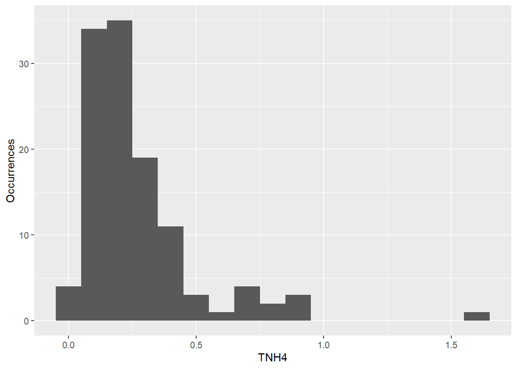

```
##    Min. 1st Qu.  Median    Mean 3rd Qu.    Max.    NA's
##  0.0305  0.1291  0.2019  0.2641  0.3215  1.5678       5
```

Calcium’s chart again shows that calcium is usually found in small amounts. However, there is 3 occurrences that can be seen on the high side.

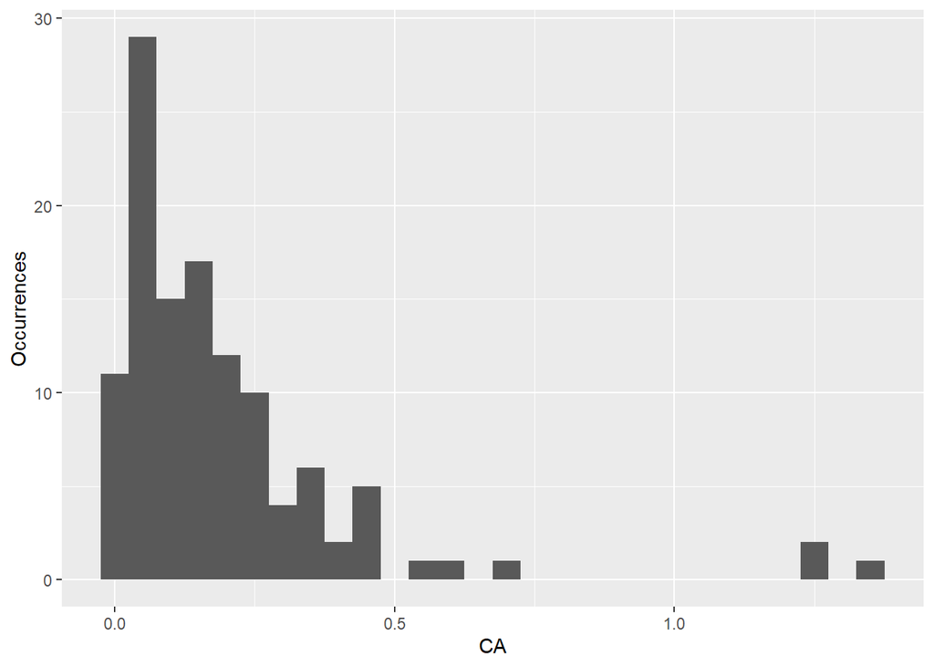

```
##    Min. 1st Qu.  Median    Mean 3rd Qu.    Max.    NA's
##  0.0125  0.0489  0.1294  0.1940  0.2543  1.3536       5
```

Magnesium exhibits the same characteristics of low level concentrations.

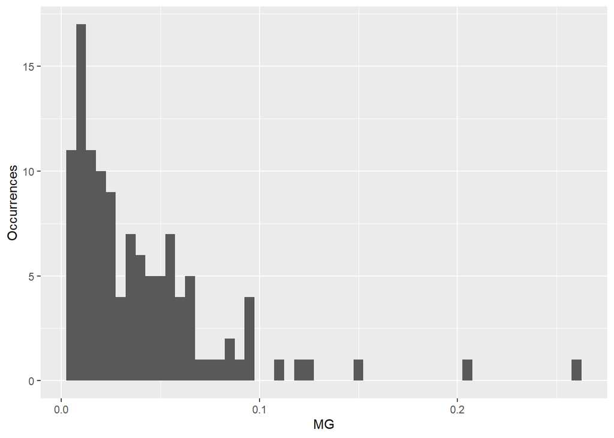

```
##    Min. 1st Qu.  Median    Mean 3rd Qu.    Max.    NA's
## 0.00370 0.01350 0.02810 0.04012 0.05590 0.25980       5
```

Sodium is completely below the 1 micro-gram level with most closer to the non-existent levels.

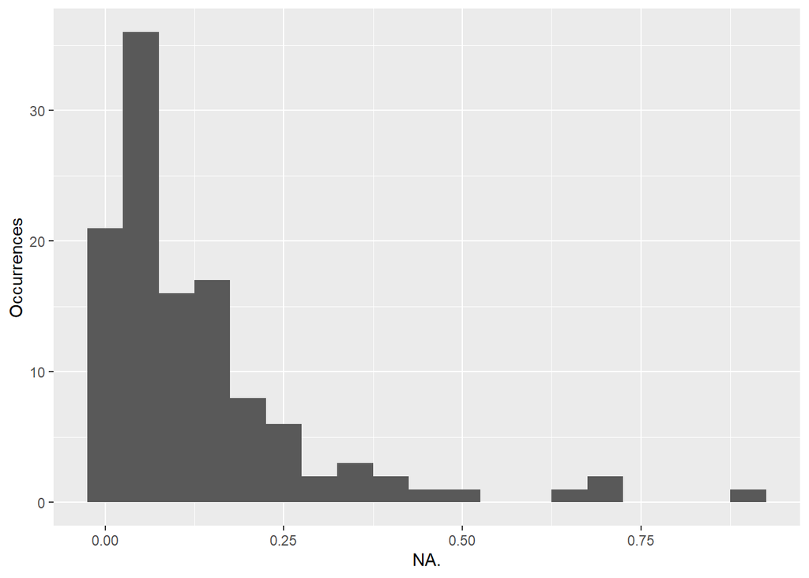

```
##    Min. 1st Qu.  Median    Mean 3rd Qu.    Max.    NA's
##  0.0076  0.0315  0.0764  0.1315  0.1670  0.9180       5
```

Potassium’s occurrences are below .5 micro-grams for all occurrences.

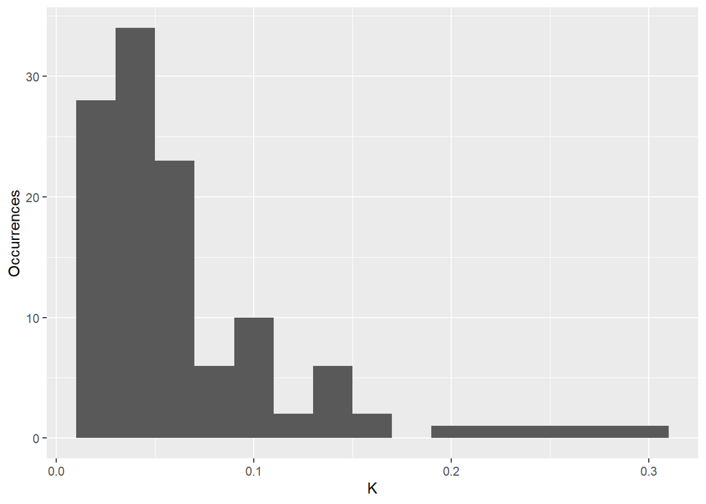

```
##    Min. 1st Qu.  Median    Mean 3rd Qu.    Max.    NA's
## 0.01020 0.03070 0.04790 0.06513 0.08140 0.29150       5
```

This sulfate graph shows the results from a nylon filter versus the teflon filter of the previous graph. Nylon provides for more refined capture of material. Becuase of this smaller pore size the sample is smaller. The graph shows that Sulfate is concentrated below the .3 micro-gram level with few outliers.

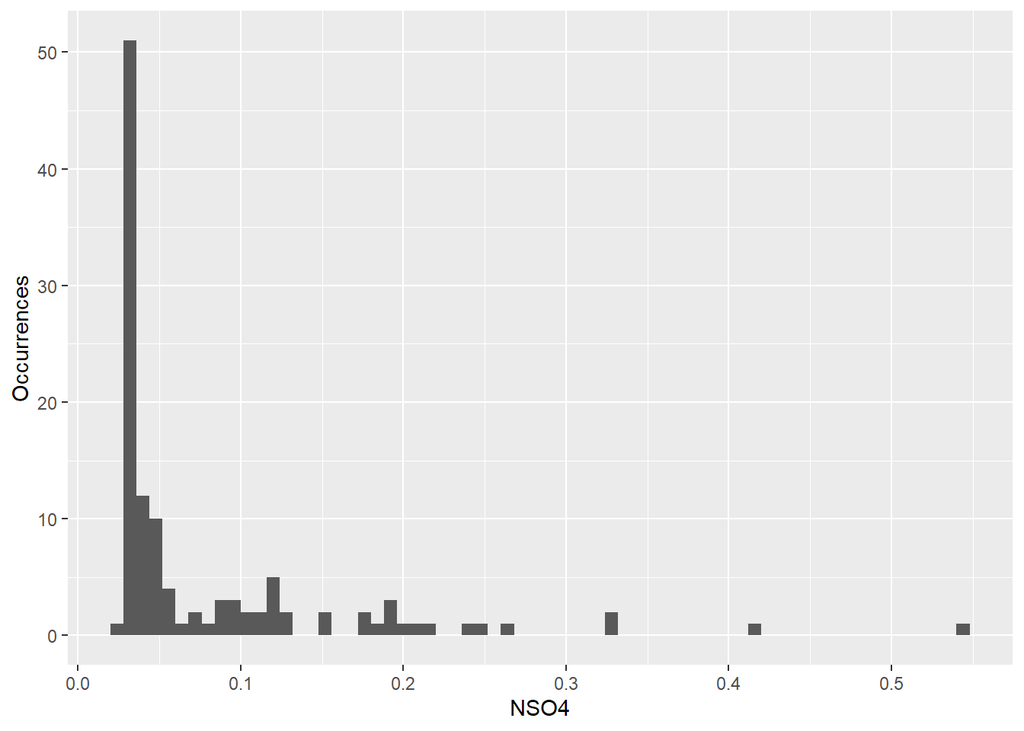

```
##    Min. 1st Qu.  Median    Mean 3rd Qu.    Max.    NA's
## 0.02430 0.03140 0.04070 0.07969 0.09430 0.54640       5
```

Nitric Acid is a strong acid that causes acid rain when present in the air. The levels of Nitric Acid in the samples are concentrated below 2 micro-grams.

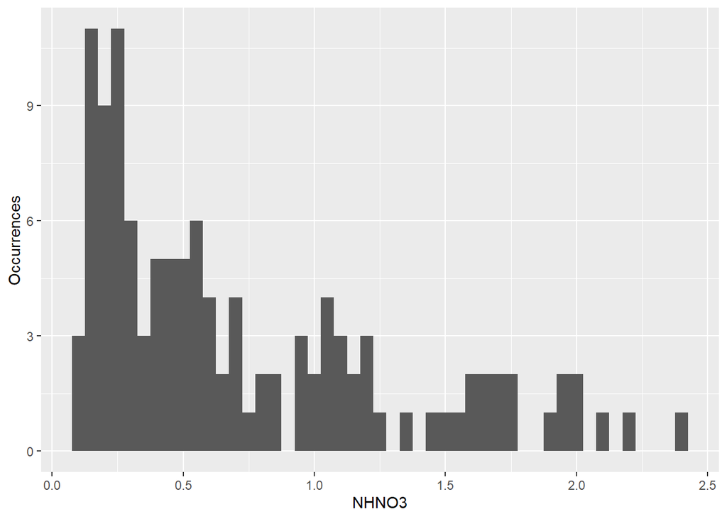

```
##    Min. 1st Qu.  Median    Mean 3rd Qu.    Max.    NA's
##  0.1016  0.2450  0.5378  0.7281  1.0649  2.3965       5
```

Another contributor to acid rain is Sulfur Dioxide. The below graph shows that Sulfur Dioxide is mainly concentrated below the 1 micro-gram level.

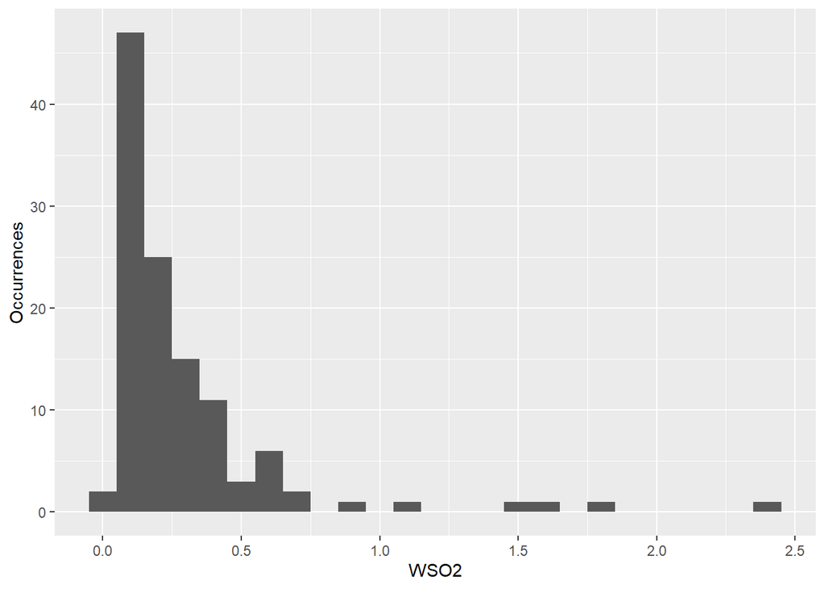

```
##    Min. 1st Qu.  Median    Mean 3rd Qu.    Max.    NA's
##  0.0463  0.1099  0.1697  0.2912  0.3440  2.3669       5
```

Below is a snap shot of all the above graphs in one.

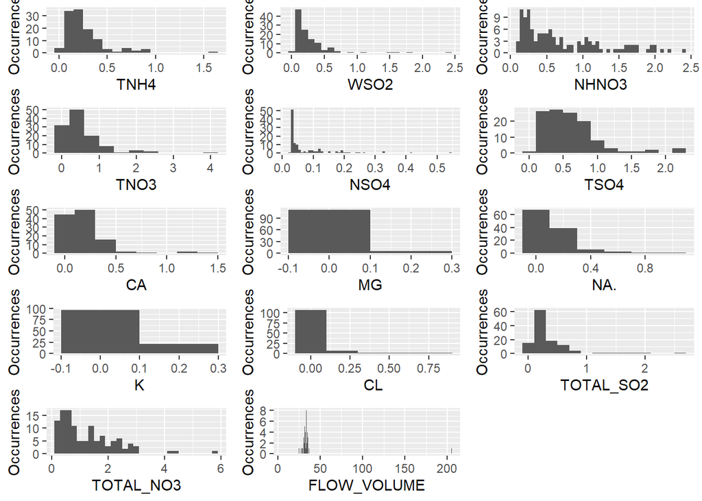

Glacier National Park is used as our baseline for our comparison as it experiences the best Air Quality rating in the US.

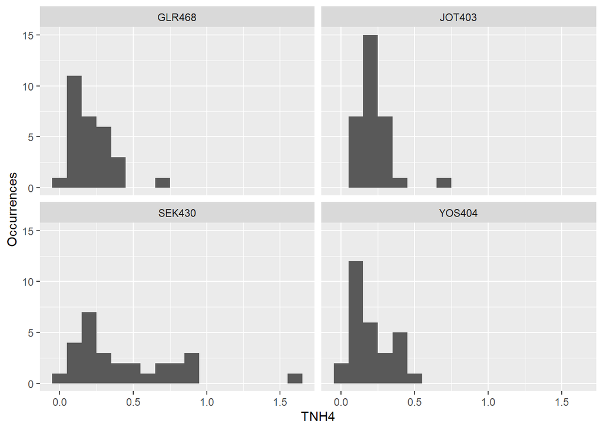

This graph shows that YOS404 is the only site that experiences less Ammonium amongst the four locations.

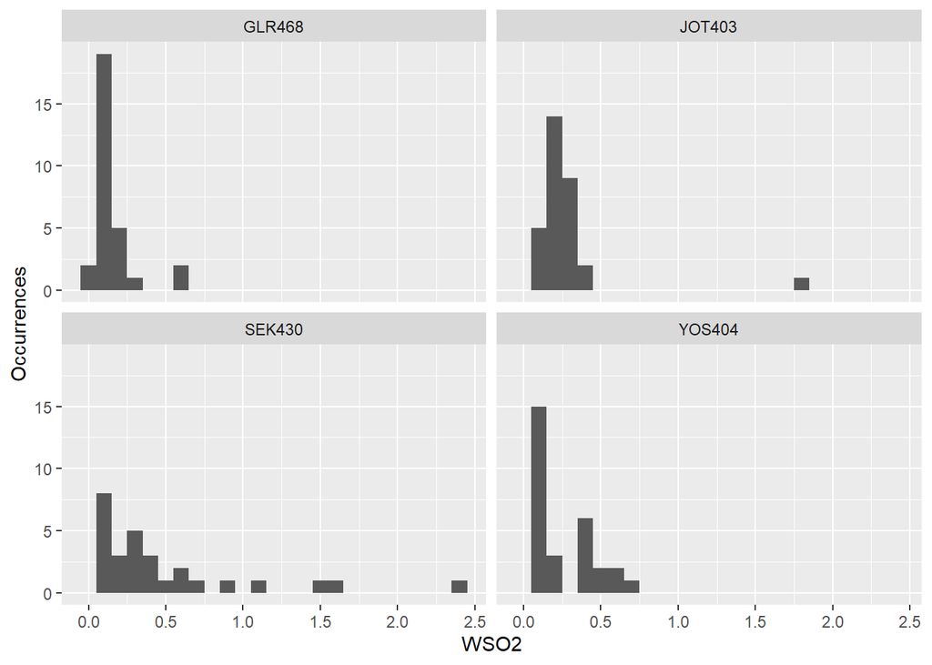

GLR468’s Sulfur Dioxide is much lower than SEK430 and YOS 404. However, the concentration for JOT403 and GLR468 are both between 0 and .5 micro-grams.

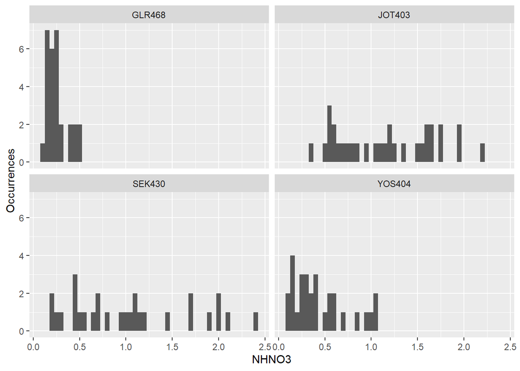

Nitric Acid is extremelow in GLR468. However, JOT403 and SEK430 has nitric acid measurements from .5 to 2.25 micro-grams.

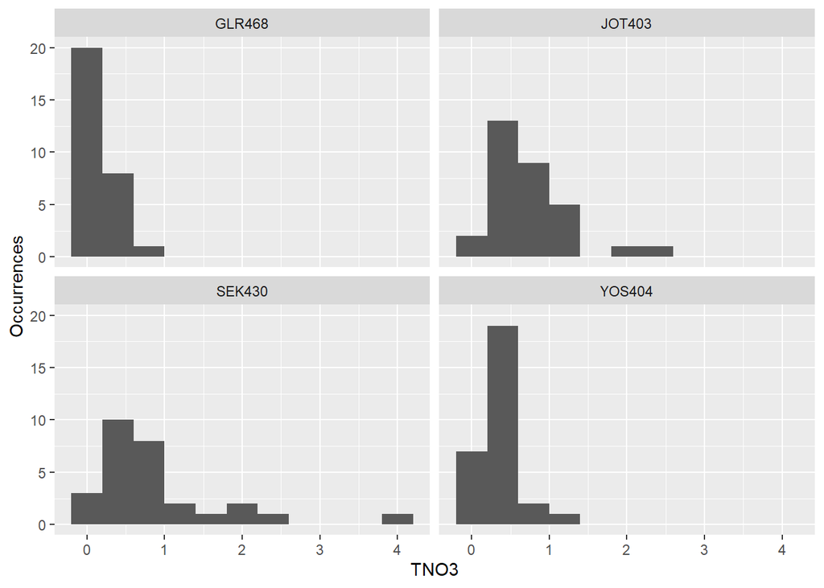

Nitrate is significantly lower in GLR 468 and only comparable to YOS404.

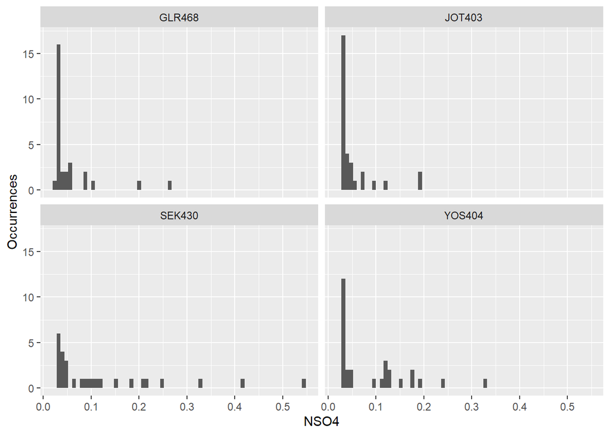

SEK 430 sees Sulfate measurements from 0 to .5 micro-grams. While GLR468 and JOT403 maintain levels at .1.

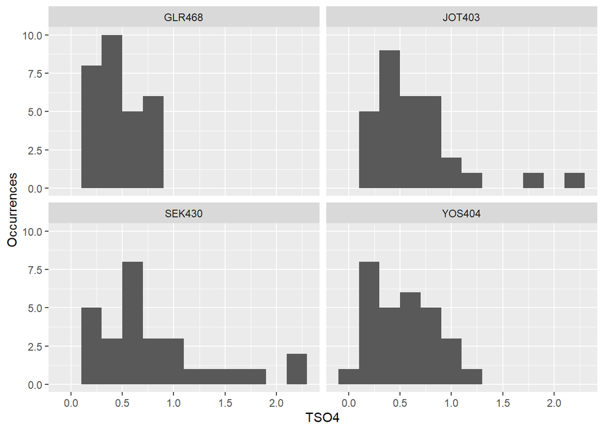

Sulfate through the Teflon filter shows the same as the Nylon filter.

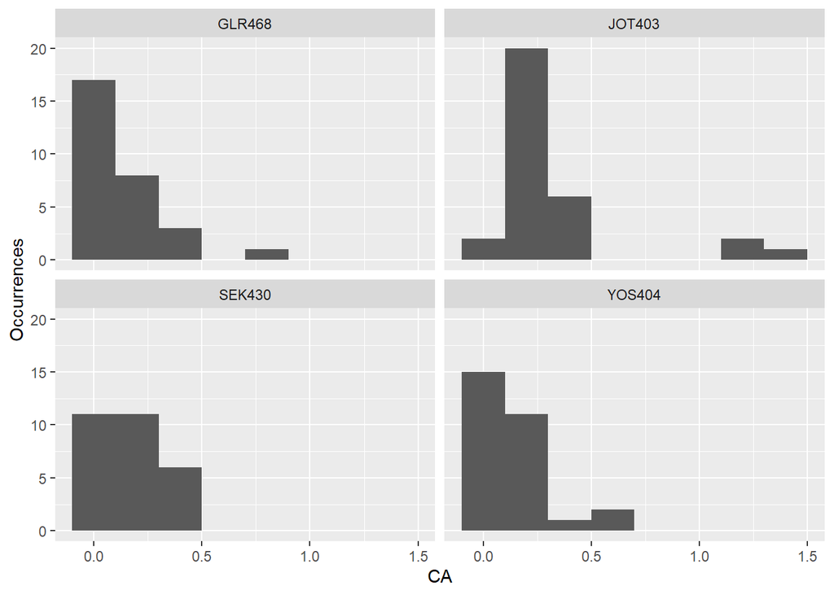

Calcium measured in GLR468, SEK430, and YOS40 are equal and mainly below the .5 micro-gram level.

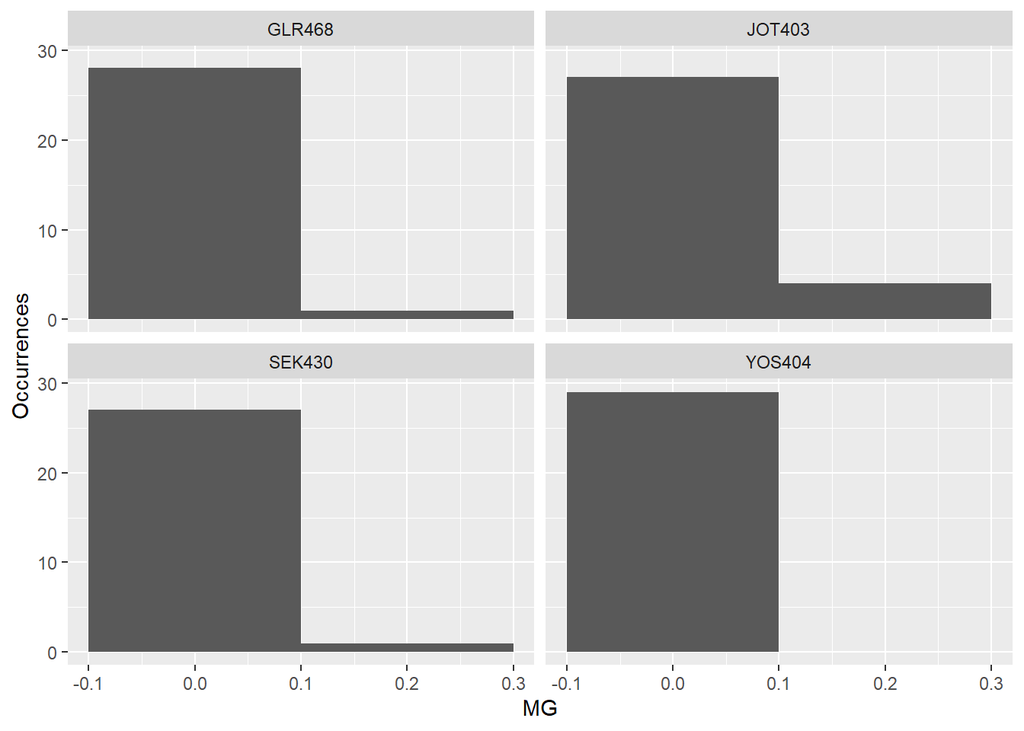

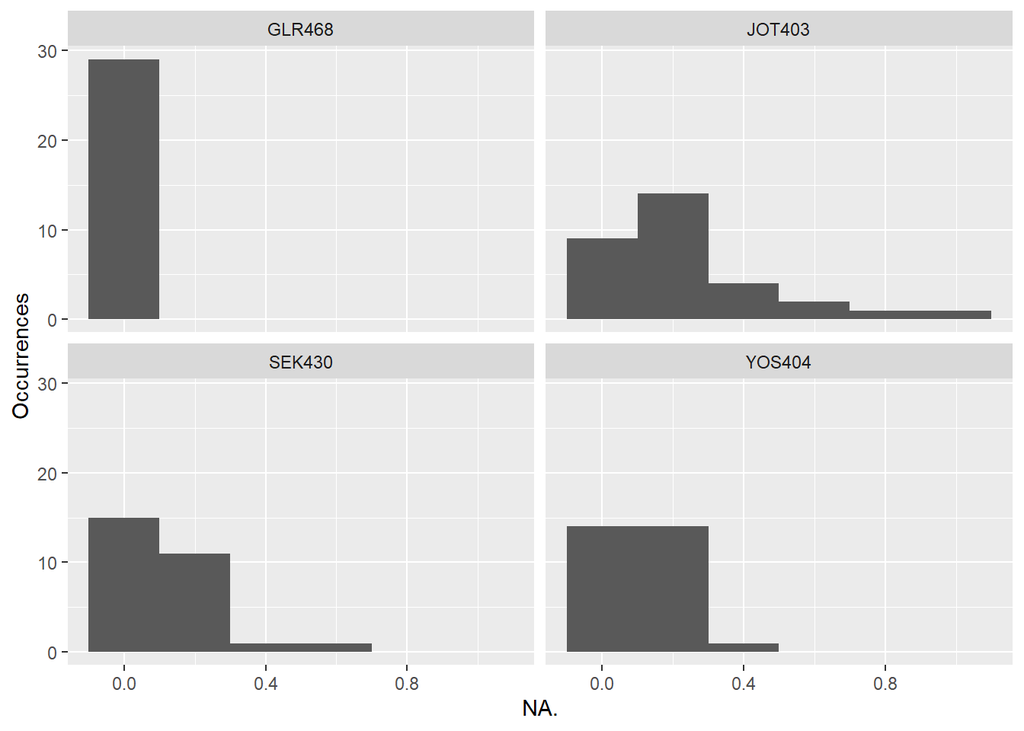

Sodium is not present in GLR468 but is prevalent in JOT403.

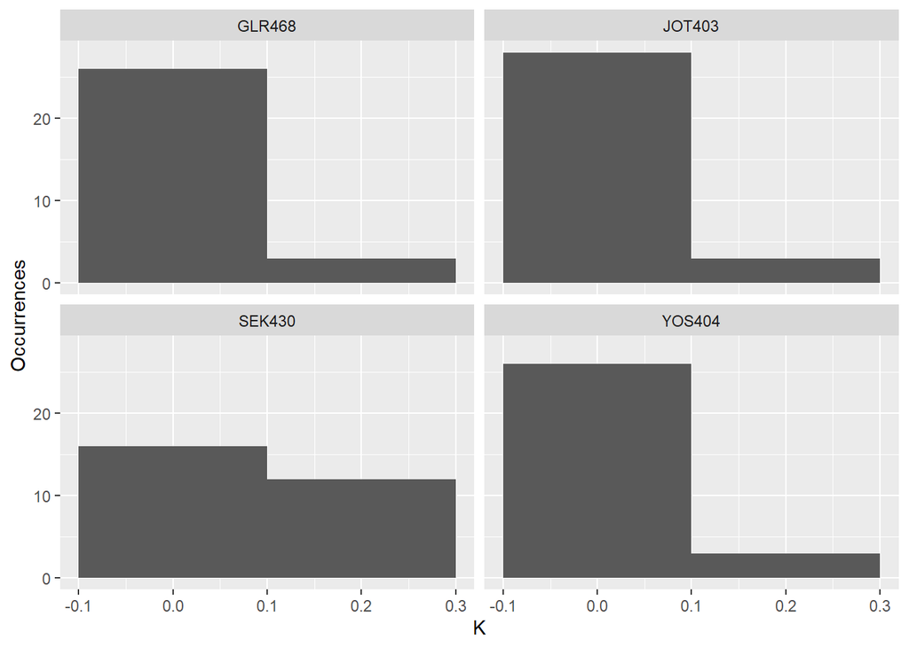

Chloride is mostly not present in all location. However, JOT403 and SEK430 does have multiple occurrences of chloride.

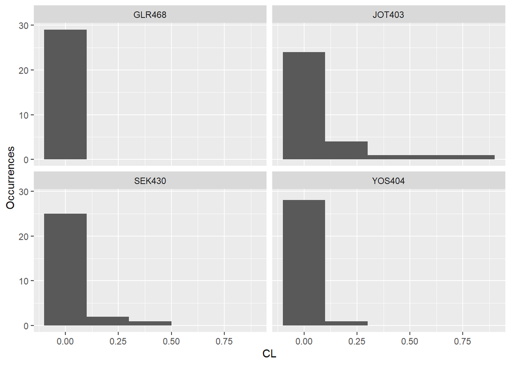

# Univariate Analysis

### What is the structure of your dataset?

Other Observations:

Based on “https://www.epa.gov/castnet/castnet-ozone-monitoring” website Glacier National Park’s GLR468 had the lowest 8-hour daily maximum ozone concentration at 53. This 53 is tied for the lowest concentration for the United States.

Contrarily, YOS404 (Turtleback Dome - Yosemite National Park), SEK430 (Ash Mountain - Sequoia National Park), JOT403 (Joshua Tree National Park) had ratings of 77, 85, 88 respectively. These rating are the highest in the nation and are all in California.

### Did you create any new variables from existing variables in the dataset?

### Of the features you investigated, were there any unusual distributions?

Did you perform any operations on the data to tidy, adjust, or change the form  
of the data? If so, why did you do this?

# Bivariate Plots Section

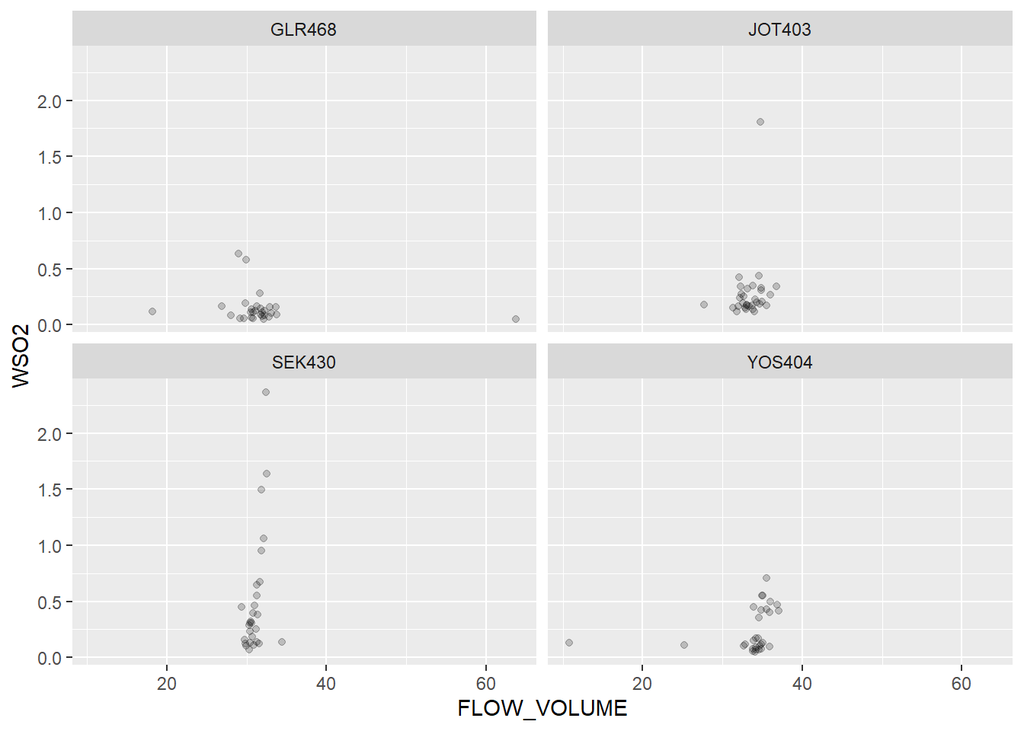

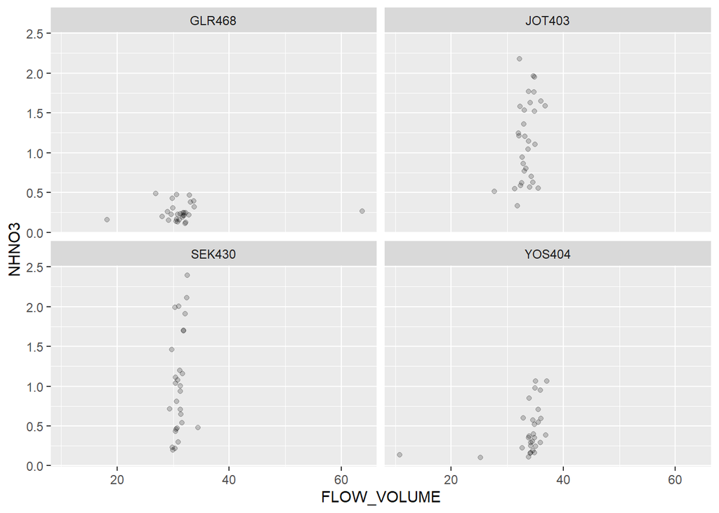

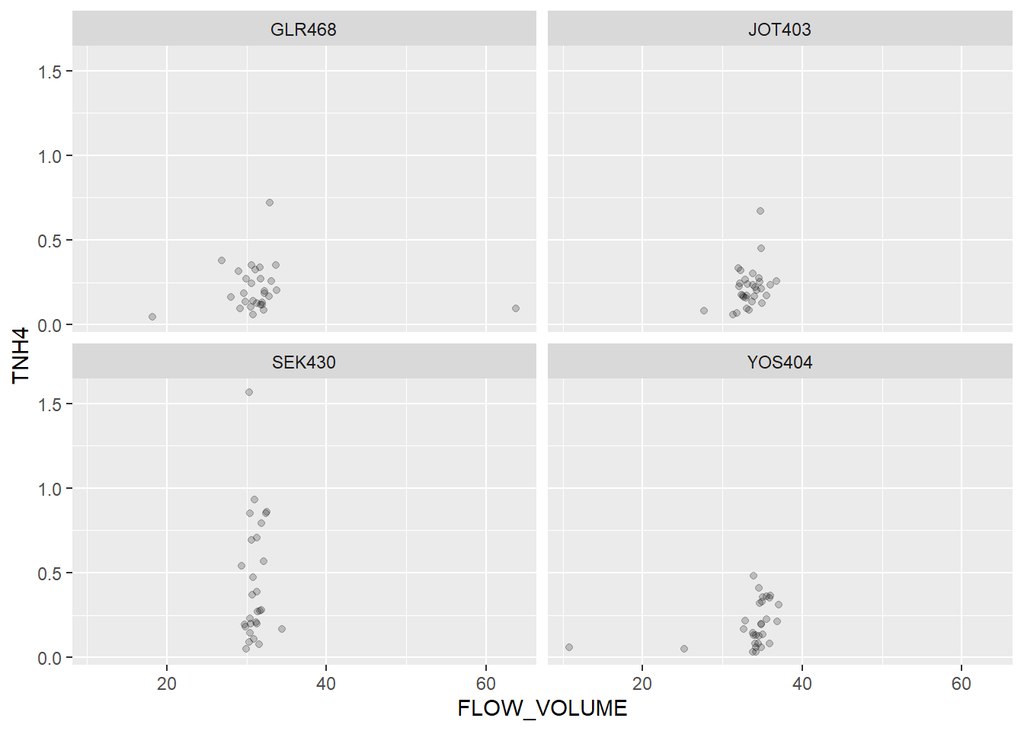

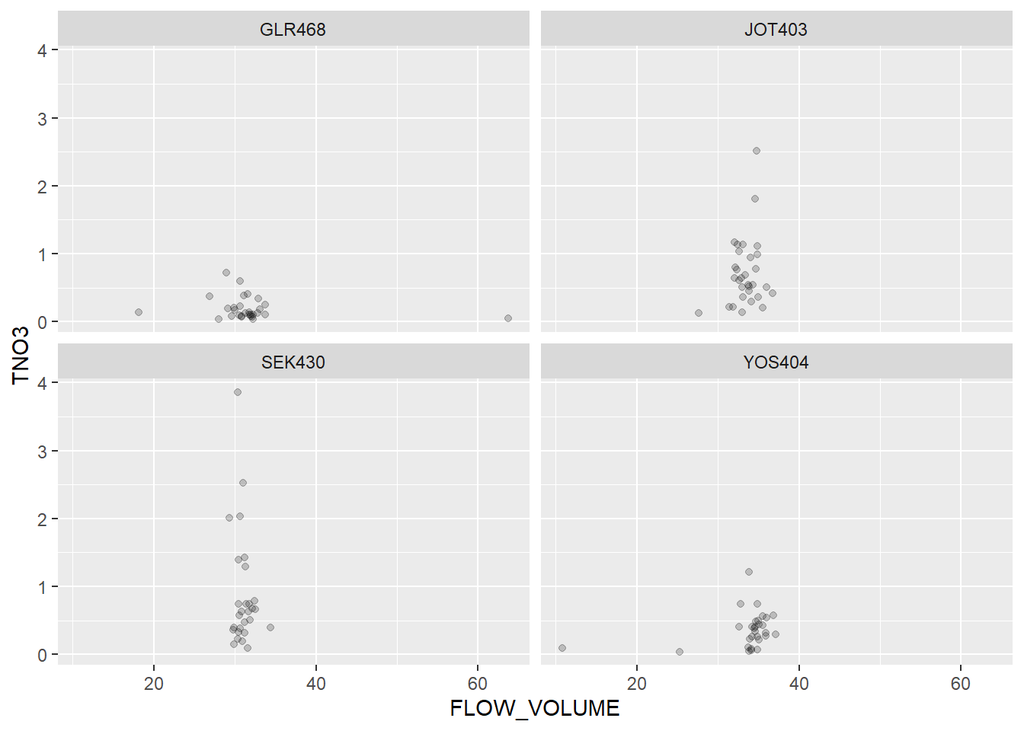

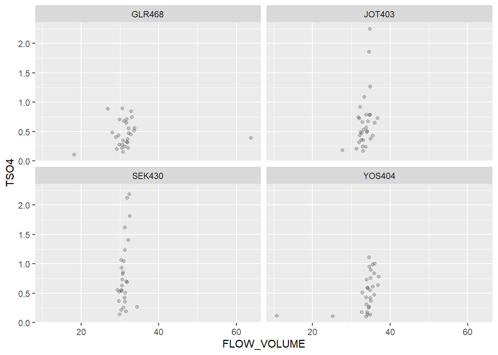

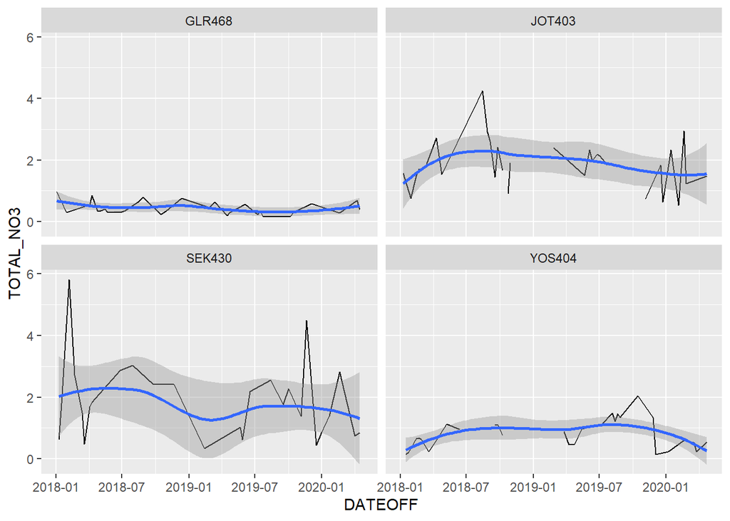

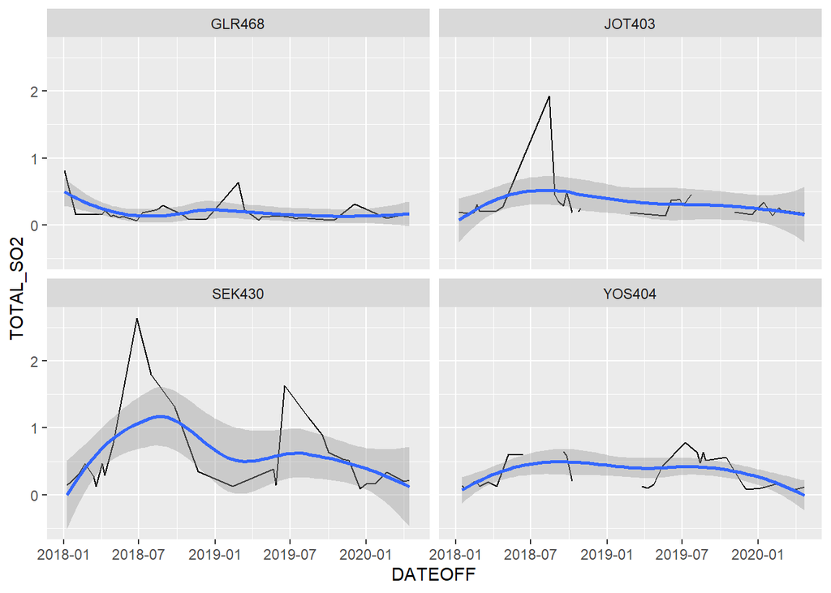

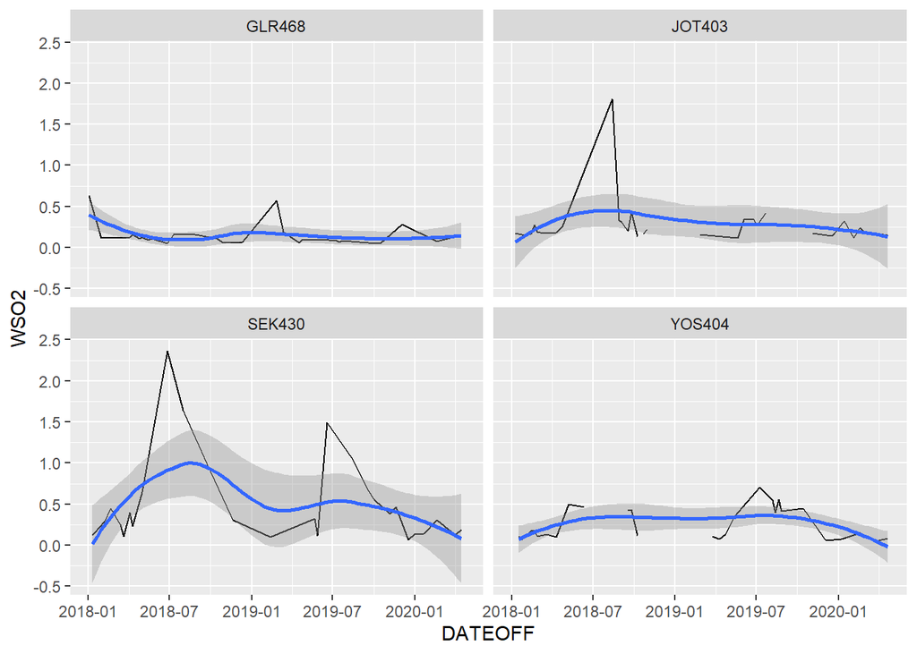

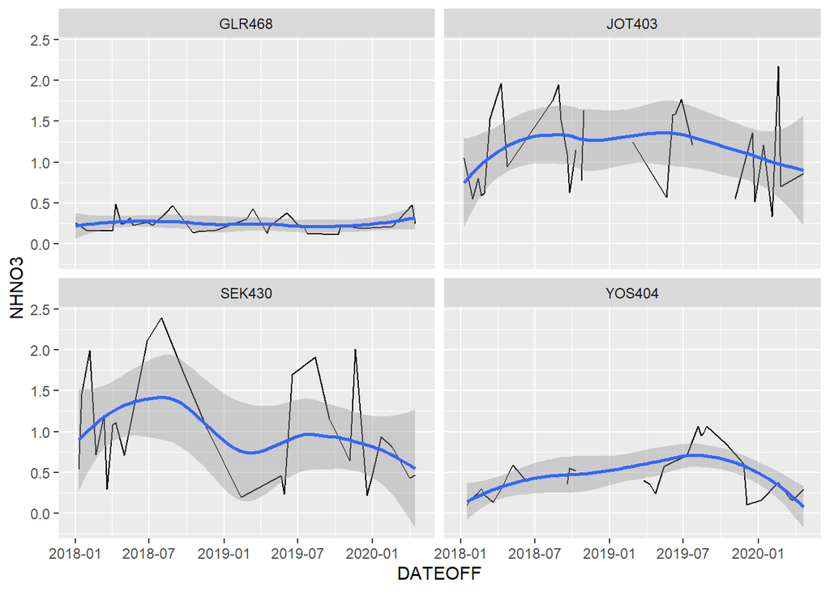